# finalproject

```python
import pandas as pd
data = pd.read_csv("unemploy.csv")
```

```python
data.columns
```

```
Index(['Area Type', 'Area Name', 'Date', 'Year', 'Month', 'Age 16-19',
       'Age 20-24', 'Age 25-34', 'Age 35-44', 'Age 45-54', 'Age 55-64',
       'Age 65+'],
      dtype='object')
```

```python
data.head()
```

|  | Area Type | Area Name | Date | Year | Month | Age 16-19 | Age 20-24 | Age 25-34 | Age 35-44 | Age 45-54 | Age 55-64 | Age 65+ |
| --- | --- | --- | --- | --- | --- | --- | --- | --- | --- | --- | --- | --- |
| 0 | State | California | 2/1/2008 | 2008 | February | 0.184 | 0.093 | 0.053 | 0.040 | 0.041 | 0.039 | 0.048 |
| 1 | State | California | 3/1/2008 | 2008 | March | 0.187 | 0.096 | 0.054 | 0.041 | 0.042 | 0.038 | 0.050 |
| 2 | State | California | 4/1/2008 | 2008 | April | 0.187 | 0.097 | 0.055 | 0.043 | 0.043 | 0.037 | 0.050 |
| 3 | State | California | 5/1/2008 | 2008 | May | 0.187 | 0.101 | 0.057 | 0.044 | 0.045 | 0.036 | 0.050 |
| 4 | State | California | 6/1/2008 | 2008 | June | 0.191 | 0.105 | 0.059 | 0.044 | 0.046 | 0.038 | 0.048 |

```python
data.tail()
```

|  | Area Type | Area Name | Date | Year | Month | Age 16-19 | Age 20-24 | Age 25-34 | Age 35-44 | Age 45-54 | Age 55-64 | Age 65+ |
| --- | --- | --- | --- | --- | --- | --- | --- | --- | --- | --- | --- | --- |
| 189 | State | California | 11/1/2023 | 2023 | November | 0.159 | 0.080 | 0.052 | 0.039 | 0.028 | 0.033 | 0.039 |
| 190 | State | California | 12/1/2023 | 2023 | December | 0.168 | 0.079 | 0.053 | 0.039 | 0.029 | 0.034 | 0.037 |
| 191 | State | California | 1/1/2024 | 2024 | January | 0.169 | 0.079 | 0.053 | 0.040 | 0.032 | 0.035 | 0.039 |
| 192 | State | California | 2/1/2024 | 2024 | February | 0.175 | 0.081 | 0.052 | 0.040 | 0.033 | 0.035 | 0.040 |
| 193 | State | California | 3/1/2024 | 2024 | March | 0.179 | 0.083 | 0.052 | 0.039 | 0.033 | 0.034 | 0.040 |

```python
data.shape
```

```
(194, 12)
```

```python
data.isnull().sum()
```

```
Area Type    0
Area Name    0
Date         0
Year         0
Month        0
Age 16-19    0
Age 20-24    0
Age 25-34    0
Age 35-44    0
Age 45-54    0
Age 55-64    0
Age 65+      0
dtype: int64
```

```python
data.duplicated().sum()
```

```
0
```

```python
data.dtypes
```

```
Area Type     object
Area Name     object
Date          object
Year           int64
Month         object
Age 16-19    float64
Age 20-24    float64
Age 25-34    float64
Age 35-44    float64
Age 45-54    float64
Age 55-64    float64
Age 65+      float64
dtype: object
```

```python
data.sort_values("Date")
```

|  | Area Type | Area Name | Date | Year | Month | Age 16-19 | Age 20-24 | Age 25-34 | Age 35-44 | Age 45-54 | Age 55-64 | Age 65+ |
| --- | --- | --- | --- | --- | --- | --- | --- | --- | --- | --- | --- | --- |
| 11 | State | California | 1/1/2009 | 2009 | January | 0.252 | 0.126 | 0.076 | 0.061 | 0.055 | 0.046 | 0.056 |
| 23 | State | California | 1/1/2010 | 2010 | January | 0.332 | 0.173 | 0.118 | 0.097 | 0.089 | 0.087 | 0.091 |
| 35 | State | California | 1/1/2011 | 2011 | January | 0.339 | 0.189 | 0.120 | 0.107 | 0.099 | 0.095 | 0.092 |
| 47 | State | California | 1/1/2012 | 2012 | January | 0.352 | 0.174 | 0.114 | 0.091 | 0.099 | 0.095 | 0.092 |
| 59 | State | California | 1/1/2013 | 2013 | January | 0.347 | 0.158 | 0.101 | 0.083 | 0.081 | 0.082 | 0.090 |
| ... | ... | ... | ... | ... | ... | ... | ... | ... | ... | ... | ... | ... |
| 139 | State | California | 9/1/2019 | 2019 | September | 0.146 | 0.074 | 0.040 | 0.028 | 0.034 | 0.033 | 0.035 |
| 151 | State | California | 9/1/2020 | 2020 | September | 0.221 | 0.146 | 0.095 | 0.071 | 0.072 | 0.075 | 0.088 |
| 163 | State | California | 9/1/2021 | 2021 | September | 0.174 | 0.127 | 0.082 | 0.067 | 0.066 | 0.073 | 0.080 |
| 175 | State | California | 9/1/2022 | 2022 | September | 0.116 | 0.075 | 0.045 | 0.040 | 0.031 | 0.038 | 0.044 |
| 187 | State | California | 9/1/2023 | 2023 | September | 0.139 | 0.081 | 0.050 | 0.039 | 0.030 | 0.030 | 0.038 |

194 rows × 12 columns

What age group has consistently had the highest unemployment rates over the entire time period and what could this indicate about their job market stability?

```python
highest_unemployment_by_age = data[['Age 16-19', 'Age 20-24', 'Age 25-34', 'Age 35-44', 'Age 45-54', 'Age 55-64', 'Age 65+']].idxmax(axis=1).value_counts().idxmax()
highest_unemployment_by_age
```

```
'Age 16-19'
```

Has there been a general trend of increasing or decreasing unemployment among the youngest (16-19) and oldest (65+) age groups, potentially indicating economic shifts affecting these demographics?

```python
trend_youngest = data.pivot_table(values='Age 16-19', index='Year', aggfunc='mean').diff().dropna()
trend_oldest = data.pivot_table(values='Age 65+', index='Year', aggfunc='mean').diff().dropna()
trend_youngest
```

| Year | Age 16-19 |
| --- | --- |
| 2009 | 0.080826 |
| 2010 | 0.054583 |
| 2011 | -0.000250 |
| 2012 | 0.010667 |
| 2013 | -0.032667 |
| 2014 | -0.036667 |
| 2015 | -0.059083 |
| 2016 | -0.036250 |
| 2017 | -0.003500 |
| 2018 | -0.023417 |
| 2019 | -0.012167 |
| 2020 | 0.044083 |
| 2021 | 0.005083 |
| 2022 | -0.074000 |
| 2023 | 0.010750 |
| 2024 | 0.038250 |

```python
trend_oldest
```

| Year | Age 65+ |
| --- | --- |
| 2009 | 0.023902 |
| 2010 | 0.013417 |
| 2011 | 0.011250 |
| 2012 | -0.005750 |
| 2013 | -0.020250 |
| 2014 | -0.018917 |
| 2015 | 0.003500 |
| 2016 | -0.015500 |
| 2017 | 0.003667 |
| 2018 | -0.011083 |
| 2019 | -0.001833 |
| 2020 | 0.034917 |
| 2021 | 0.024667 |
| 2022 | -0.037000 |
| 2023 | -0.018333 |
| 2024 | 0.002833 |

Which month of the year, on average, has the highest unemployment rate, suggesting seasonal trends in job availability?

```python
highest_unemployment_month = data.groupby('Month')[['Age 16-19', 'Age 20-24', 'Age 25-34', 'Age 35-44', 'Age 45-54', 'Age 55-64', 'Age 65+']].mean().mean(axis=1).idxmax()
highest_unemployment_month
```

```
'April'
```

Is there a significant difference in unemployment rates between younger (16-34) and middle-aged (35-54) workers, indicating potential experience or education gaps?

```python
unemployment_difference_young_middle = data[['Age 16-19', 'Age 20-24', 'Age 25-34']].mean(axis=1) - data[['Age 35-44', 'Age 45-54']].mean(axis=1)
unemployment_difference_young_middle
```

```
0      0.069500
1      0.070833
2      0.070000
3      0.070500
4      0.073333
         ...
189    0.063500
190    0.066000
191    0.064333
192    0.066167
193    0.068667
Length: 194, dtype: float64
```

What is the median unemployment rate for each age group, and how does this reflect on the overall economic health of these demographics?

```python
median_unemployment_by_age = data[['Age 16-19', 'Age 20-24', 'Age 25-34', 'Age 35-44', 'Age 45-54', 'Age 55-64', 'Age 65+']].median()
median_unemployment_by_age
```

```
Age 16-19    0.2125
Age 20-24    0.1135
Age 25-34    0.0710
Age 35-44    0.0530
Age 45-54    0.0525
Age 55-64    0.0540
Age 65+      0.0545
dtype: float64
```

After the last economic recession (date to be specified), how quickly did each age group recover, based on unemployment rates, to pre-recession levels?

```python
# Assuming the recession ended in 2012, as an example.
recovery_post_recession = data.query('Year > 2012').groupby('Year').mean(numeric_only=True).pct_change().fillna(0).cumsum()
recovery_post_recession
```

| Year | Age 16-19 | Age 20-24 | Age 25-34 | Age 35-44 | Age 45-54 | Age 55-64 | Age 65+ |
| --- | --- | --- | --- | --- | --- | --- | --- |
| 2013 | 0.000000 | 0.000000 | 0.000000 | 0.000000 | 0.000000 | 0.000000 | 0.000000 |
| 2014 | -0.114137 | -0.141689 | -0.114828 | -0.135048 | -0.107551 | -0.222222 | -0.260023 |
| 2015 | -0.321751 | -0.285816 | -0.260896 | -0.368010 | -0.342167 | -0.333179 | -0.195007 |
| 2016 | -0.482505 | -0.461632 | -0.397259 | -0.506944 | -0.506321 | -0.501666 | -0.465356 |
| 2017 | -0.500999 | -0.581344 | -0.534378 | -0.572610 | -0.632573 | -0.535437 | -0.377707 |
| 2018 | -0.627064 | -0.705066 | -0.601794 | -0.785461 | -0.758720 | -0.702427 | -0.621297 |
| 2019 | -0.702013 | -0.660726 | -0.734324 | -0.884951 | -0.682605 | -0.786343 | -0.674565 |
| 2020 | -0.408450 | -0.071899 | 0.003771 | -0.035092 | -0.014312 | 0.017728 | 0.397046 |
| 2021 | -0.382281 | 0.151027 | 0.303999 | 0.360007 | 0.292705 | 0.402777 | 0.762478 |
| 2022 | -0.753519 | -0.258404 | -0.140250 | -0.037358 | -0.179330 | -0.039178 | 0.361031 |
| 2023 | -0.667748 | -0.359670 | -0.230297 | -0.219508 | -0.444161 | -0.343923 | 0.028705 |
| 2024 | -0.386670 | -0.306582 | -0.140020 | -0.159374 | -0.314478 | -0.252059 | 0.105628 |

1. Highest Unemployment Rate by Age Group Over Time:

Our analysis reveals a consistent pattern in California's job market: the youngest workers, specifically those aged 16-19, face the highest unemployment rates. This trend may point to the obstacles that entry-level workers encounter, such as lack of experience or competition with more seasoned workers. It's a call to action for workforce development programs to focus on this age group to provide them with the skills and opportunities needed to secure employment.

4. Unemployment Rates Difference Between Younger and Middle-Aged Workers:

A significant gap exists between the unemployment rates of younger (16-34) and middle-aged (35-54) workers. This suggests that experience and possibly education contribute to job stability. Initiatives to bridge this gap could include mentorship programs, internships, and more accessible education opportunities, highlighting the importance of continuous learning and skill development.

5. Median Unemployment Rate Reflecting Economic Health:

Analyzing the median unemployment rate across different age groups sheds light on the broader economic health impacting these demographics. A relatively stable median rate suggests that despite economic ups and downs, the core employment challenges for certain age groups remain unchanged. Addressing these persistent issues is vital for sustainable economic growth and social stability.

6. Economic Recovery Post-Recession:

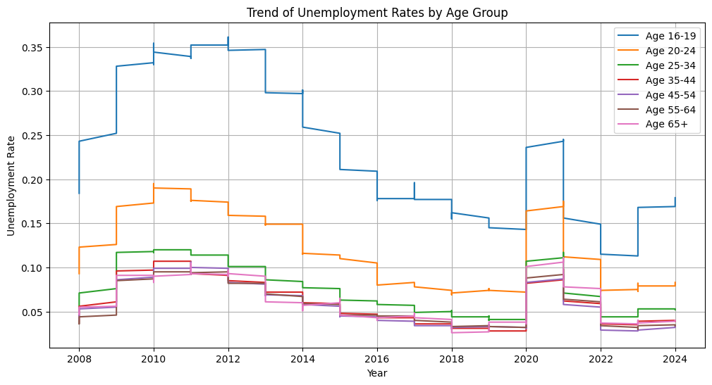

```python
import matplotlib.pyplot as plt

# Assuming 'data' is your DataFrame and it has been preprocessed correctly.

# 1. Line plot for trend of unemployment rates over the years for all age groups
plt.figure(figsize=(12, 6))
for age_group in ['Age 16-19', 'Age 20-24', 'Age 25-34', 'Age 35-44', 'Age 45-54', 'Age 55-64', 'Age 65+']:
    plt.plot(data['Year'], data[age_group], label=age_group)
plt.xlabel('Year')
plt.ylabel('Unemployment Rate')
plt.title('Trend of Unemployment Rates by Age Group')
plt.legend()
plt.grid(True)
plt.show()
```

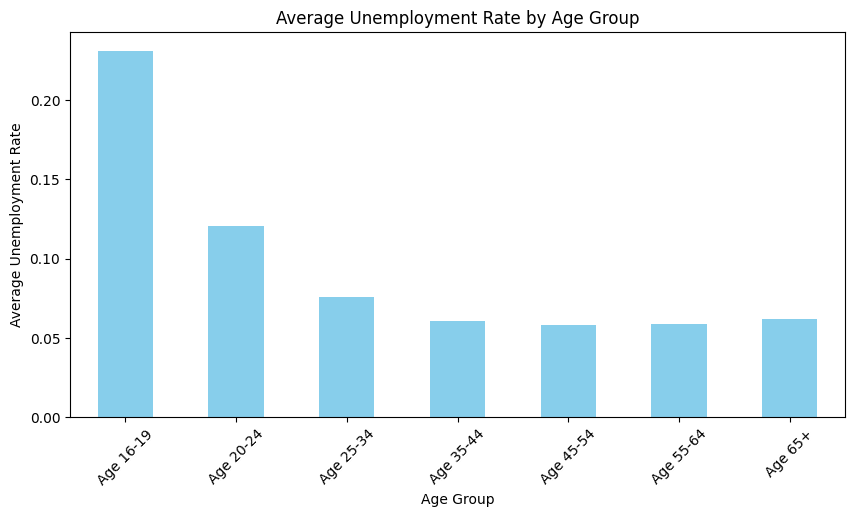

```python
# 2. Bar plot to compare the average unemployment rates across age groups
avg_unemployment = data[['Age 16-19', 'Age 20-24', 'Age 25-34', 'Age 35-44', 'Age 45-54', 'Age 55-64', 'Age 65+']].mean()
plt.figure(figsize=(10, 5))
avg_unemployment.plot(kind='bar', color='skyblue')
plt.xlabel('Age Group')
plt.ylabel('Average Unemployment Rate')
plt.title('Average Unemployment Rate by Age Group')
plt.xticks(rotation=45)
plt.show()
```

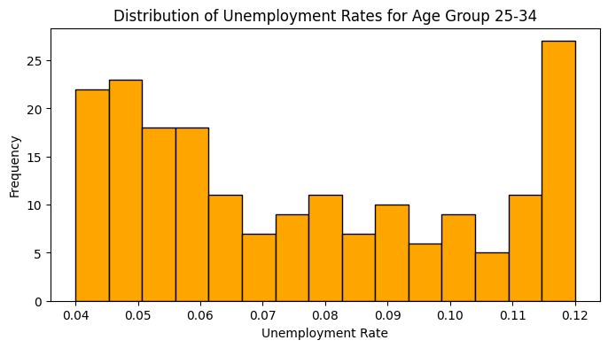

```python
# 3. Histogram to show the distribution of unemployment rates for the age group 25-34
plt.figure(figsize=(8, 4))
plt.hist(data['Age 25-34'], bins=15, color='orange', edgecolor='black')
plt.xlabel('Unemployment Rate')
plt.ylabel('Frequency')
plt.title('Distribution of Unemployment Rates for Age Group 25-34')
plt.show()
```